# Adding Random Effects in RTMB

## RTMB Sockeye Ricker

- Consider a model with a random effect for productivity,

$$\begin{align}
\log(R_i/S_i) & = \alpha_{s_i} - \beta_{s_i} S_i + \epsilon_i \\
\alpha_{s} & \sim N(\alpha_0, \eta^2) \\
\epsilon_i & \sim N(0, \sigma_{s_i}^2) \\
s & \in \{1,\ldots,n_{s}\}
\end{align}$$

## Ways to Code Random Effects

- Consider $y \sim N(\mu, \sigma)$
- Option 1: Centered
  - Write $y$ as the random variable in terms of its mean
  - `dnorm(y, mu, sigma)`
- Option 2: In between
  - Write y as a function of a standard dnormal.
  - `dnorm(z, 0, sigma)`
  - `y = mu + z`
- Option 3: Non-centered
  - Write y as a function of a standard dnormal.
  - `dnorm(z, 0, 1)`
  - `y = mu + z*sigma`
- All three are mathematically the same model, but sometimes one is easier to fit than the other.
- I like option 2 generally, but HMC (Stan) likes option 3.
- For effects that follow each other in time, write the values themselves (options 1 and 2), not standardized steps: that keeps the Hessian sparse, which is what makes RTMB fast.

## Coding in RTMB

```r
library(RTMB)

sox$stock <- as.numeric(factor(sox$PopName))
nstocks <- max(sox$stock)
set.seed(1)
parameters <- list(
  alpha0 = runif(1, 1, 3),
  re = rnorm(nstocks, 0, 0.1),
  logbeta = runif(nstocks, -1, 0),
  logsigma = runif(nstocks, -0.5, 0.5),
  logsigma_re = log(0.5)
)

sox$logRS <- log(sox$recruits/sox$spawners)

negll <- function(pars){

  getAll(pars, sox, warn = FALSE)
  beta <- exp(logbeta)

  sigma <- exp(logsigma)
  sigma_re <- exp(logsigma_re)
  alpha <- re + alpha0

  ADREPORT(alpha)

  mu <- alpha[stock] - beta[stock]*spawners_scaled
  logRS <- OBS(logRS)

  ll <- sum(dnorm(re, 0, sigma_re, log = TRUE))
  ll <- ll + sum(dnorm(logRS, mu, sigma[stock], log = TRUE))

  return(-ll)
}

## No `random` argument yet: this maximizes the joint likelihood of the data AND the random effects
obj <- MakeADFun(func = negll, parameters = parameters, silent = TRUE)
fit <- nlminb(obj$par, obj$fn, obj$gr, control = list(eval.max = 1e4, iter.max = 1e4))
fit$message
```

```
[1] "false convergence (8)"
```

```r
exp(fit$par["logsigma_re"])   ## something has gone wrong...
```

```
 logsigma_re
1.161422e-08
```

## Fitting Random Effects

- A random effect is an unobserved random variable in the model
- We cannot do direct maximization on the joint likelihood
  - That is what the previous slide tried: the joint likelihood can always be increased by shrinking the random effects and their standard deviation towards zero together
- Options are:
  - Use MCMC and sample the random effects
  - Use the EM algorithm to find the expected values of the random effects and find the MLE of an objective function.
  - Marginalize (integrate) out the unobserved random variables and maximize the ‘marginal’ likelihood.
- RTMB (TMB) is built to marginalize

## Marginal Likelihood

- For discrete distributions, we can simply sum over the unobserved variables
- People might be familiar with zero-inflation models

$$\begin{align}
x|z & = \text{Poisson}(\lambda z)\\
z & \sim \text{Bernoulli}(p)
\end{align}$$

- In this case, the unconditional (marginal) distribution of $x$ is

$$p(x) = p(z = 0)\,I(x = 0) + p(z=1)\,p(x|z = 1)$$

## Marginal Likelihood

- To marginalize continuous random variable, need to integrate joint density is $f(\textbf{x}, \textbf{u})$,

$$f(\textbf{x}) = \int_{\Omega} f(\textbf{x} | \textbf{u})f(\textbf{u}) d\textbf{u}$$

- Simplest way to solve this is ‘brute force’, by summing over small chunks.

```r
dmarg <- function(x, mu, sigma, sigma_re){
  re <- seq(-5, 5, by = 0.01)
  pdens <- exp(dnorm(x, mu + re, sigma, log = TRUE) + dnorm(re, 0, sigma_re, log = TRUE))
  sum(pdens)*0.01
}
dmarg(0.5, 1, 0.5, 0.25)          ## Brute Force Integral
```

```
[1] 0.4783737
```

```r
dnorm(0.5, 1, sqrt(0.5^2+0.25^2)) ## Known Marginal
```

```
[1] 0.4783737
```

## Laplace Approximation

- Consider the function $f(x)$, that is complex and hard to integrate
- If we make some assumptions that it is approximately Gaussian,

$$f(x) \approx f(\widehat{x}) \sqrt{2\pi}\sigma \, N(x; \widehat{x}, \sigma^2),$$
where $\widehat{x}$ is the mode of $f$, and $\sigma^2 = \frac{1}{-\log(f(x))''_\widehat{x}}$, from the second derivative evaluated at the mode.

- This function is easy to integrate as a Normal distribution and

$$\begin{align}
\int_{-\infty}^{\infty} f(x)dx & \approx f(\widehat{x}) \sqrt{2\pi}\sigma \int_{-\infty}^{\infty} N(x; \widehat{x}, \sigma^2) dx\\
& = f(\widehat{x}) \sqrt{2\pi}\sigma
\end{align}$$

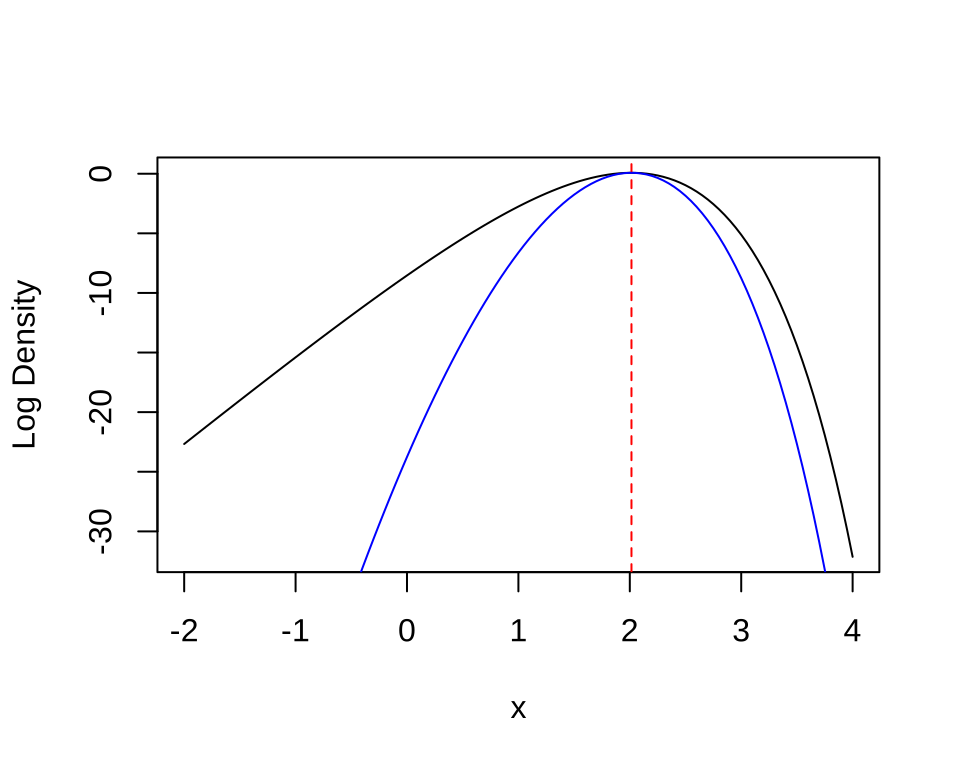

## Laplace Approximation

- Requires:
  - a smooth single peak to the likelihood distribution
  - fast + accurate gradient/hessian computation
- If highly skewed then less accurate
- With more data *for each random effect*, its likelihood is smooth and has a sharp peak. Adding more groups with little data in each does not help.
- Exact when the random effects and the data are both Gaussian. Least accurate for binary data or small counts with few observations per random effect.
- Steps are
  - Maximize $f(\textbf{x}, \textbf{u})$ with respect to the random effects, $\textbf{u}$, with fixed parameter values of $\boldsymbol{\theta}$
  - Compute Hessian and return approximate marginal likelihood

## Laplace Approximation Example 1

- A look into the black box, but can ignore the custom code.
- If we have a gamma random effect on a Poisson rate, the marginal likelihood is a negative binomial.

```r
## Equivalent to NB
r <- 5
prob <- 0.25
lambda <- rgamma(1, r, prob/(1-prob))
obs <- rpois(1, lambda)

pois_gamma <- \(theta){
  -dpois(obs, exp(theta[1]), log = TRUE) - dgamma(exp(theta[1]), theta[2], theta[3]/(1-theta[3]), log = TRUE) - theta[1]  ## Include Jacobian...
}
## Manual Laplace
nb_approx <- function(r, prob) {
  mle <- optimize(\(u){pois_gamma(c(u, r, prob))}, lower = -10, upper = 10)   ## u = log(lambda)
  u_hat <- mle$minimum
  H <- pracma::hessian(\(u){pois_gamma(c(u, r, prob))}, u_hat)
  mle$objective - 0.5 * log(2 * pi) + 0.5 * log(drop(H))
}

nb_approx(3, 0.25)
```

```
[1] 2.97263
```

```r
F <- MakeTape(pois_gamma, c(0,0, 0))
nb_approxc <- F$laplace(1)
nb_approxc(c(3, 0.25))
```

```
[1] 2.972628
```

```r
-dnbinom(obs, 3, 0.25, log = TRUE)
```

```
[1] 2.966677
```

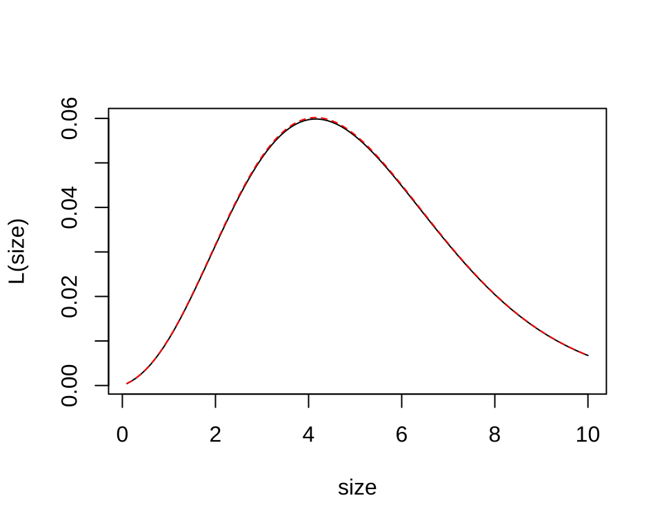

```r
size <- seq(0.1, 10, 0.1)
fapprox <- sapply(size, nb_approx, prob = 0.25)
ftrue <- sapply(size, dnbinom, x = obs, prob = 0.25, log = TRUE)
plot(size, exp(-fapprox), type = "l", ylab = "L(size)")
lines(size, exp(ftrue), type = "l", col = 'red', lty = 2)
```

## Laplace Approximation Example 2

- When you have normally distributed intercept, and normal data, the marginal likelihood of a group of observations is multivariate normal.

```r
u <- rnorm(1, 0, 2 )
x <- rnorm(5, 1+u, 1.5)

nll_joint <- function(theta) {
  -sum(dnorm(x, theta[1] + theta[2], theta[3], log = TRUE)) - dnorm(theta[1], 0, theta[4], log = TRUE)
}

## Manual Laplace
nll_approx <- function(mu, sd, sdre) {
  mle <- optimize(\(u){nll_joint(c(u, mu, sd, sdre))}, 0, lower = -100, upper = 100)
  u_hat <- mle$minimum
  H <- pracma::hessian(\(u){nll_joint(c(u, mu, sd, sdre))}, u_hat)
  mle$objective - 0.5 * log(2 * pi) + 0.5 * log(as.numeric(H))
}

## RTMB approx:
nll_rtmb <- MakeTape(nll_joint, c(0,0,1,1))
nll_approxc <- nll_rtmb$laplace(1)

## Known marginal distribution
nll_exact <- function(theta) {
  Sigma <- matrix(theta[3]^2, ncol = length(x), nrow = length(x)) + theta[2]^2*diag(length(x))
  -dmvnorm(x, mu = rep(theta[1], length(x)), Sigma = Sigma, log = TRUE)
}

# Test it:
nll_approx(1, 1.5, 2)
```

```
[1] 8.736307
```

```r
nll_approxc(c(1, 1.5, 2))
```

```
[1] 8.736307
```

```r
nll_exact(c(1, 1.5, 2))
```

```
[1] 8.736307
```

## Back to Sockeye

- RTMB makes it really easy to compute the marginal likelihood: name the random effects.

```r
obj <- MakeADFun(func = negll, parameters = parameters, random = "re", silent = TRUE)
fit <- nlminb(obj$par, obj$fn, obj$gr, control = list(eval.max = 1e4, iter.max = 1e4))
fit$message
```

```
[1] "relative convergence (4)"
```

```r
exp(fit$par["logsigma_re"])
```

```
logsigma_re
  0.1056415
```

- They even make it easy to do a basic check if the Laplace approximation is working.
  - Based on checking if gradient of negative log-likelihood is zero.
  - If approximation is bad, average gradient is not zero
  - Use many more simulations than parameters (there are 40 here). With the default `n = 100` the p-value comes out too small even when the approximation is exact, as it is for this model.

```r
check <- checkConsistency(obj, n = 2000)
s <- summary(check)
s$marginal$p.value
## Estimated bias caused by the approximation, in units of standard error
max(abs(s$marginal$bias)/sqrt(diag(sdreport(obj)$cov.fixed)))
```

[output not shown]

```r
resids <- oneStepPredict(obj, method = "fullGaussian", trace = FALSE)
qqnorm(resids$residual); abline(0,1)
```

[output not shown]

## Check Against a Package

- Before trusting a model you coded yourself, fit the same model with a package, if one can.
- `glmmTMB` can fit this one: a random intercept for each stock, a slope for each stock, and a residual standard deviation for each stock.

```r
library(glmmTMB)
fit_glmm <- glmmTMB(logRS ~ 1 + PopName:spawners_scaled + (1 | PopName),
                    dispformula = ~ 0 + PopName, data = sox)

## Negative log-likelihood and between-stock standard deviation
round(rbind(RTMB = c(nll = fit$objective, sigma_re = exp(fit$par[["logsigma_re"]])),
            glmmTMB = c(-as.numeric(logLik(fit_glmm)), attr(VarCorr(fit_glmm)$cond$PopName, "stddev"))), 3)
```

```
            nll sigma_re
RTMB    1883.81    0.106
glmmTMB 1883.81    0.106
```

```r
## glmmTMB does not force the slopes to be negative. Are they all negative anyway?
all(fixef(fit_glmm)$cond[-1] < 0)
```

```
[1] TRUE
```

- Same likelihood, same answer.

## How Well Do We Know the Variance?

- Maximum likelihood underestimates a variance when many mean parameters are estimated alongside it (the $n/(n-a)$ correction in the pre-course material).
- REML is the general fix: integrate the mean parameters out too. In RTMB, add them to `random`.
- Report an interval for a variance parameter, not just the estimate. The profile likelihood is the honest one.

```r
## REML for the common intercept: integrate alpha0 out together with the random effects
obj_reml <- MakeADFun(func = negll, parameters = parameters, random = c("re", "alpha0"), silent = TRUE)
fit_reml <- nlminb(obj_reml$par, obj_reml$fn, obj_reml$gr, control = list(eval.max = 1e4, iter.max = 1e4))
c(ML = exp(fit$par[["logsigma_re"]]), REML = exp(fit_reml$par[["logsigma_re"]]))
```

```
       ML      REML
0.1056415 0.1270060
```

```r
## 95% profile likelihood interval for sigma_re (ML fit)
prof <- TMB::tmbprofile(obj, "logsigma_re", trace = FALSE, parm.range = c(log(0.001), Inf))
exp(confint(prof))
```

```
            lower     upper
logsigma_re    NA 0.2522631
```

- No lower limit (`NA`): these data cannot rule out $\sigma_{re} = 0$, that is, no difference in productivity among stocks.
- Integrating out the 19 slopes as well (written without `exp()`, so the model is linear in them) gives full REML, which is what `glmmTMB(..., REML = TRUE)` does.

## Time Varying Productivity

- Often we expect productivity to change with time.
- Perhaps there is a global time varying productivity randomly changes, with stock specific differences.
- Let’s write that as

$$\begin{align}
\alpha_{st} & = \alpha_0 + a_t + u_s\\
a_t|a_{t-1} & \sim N(\phi a_{t-1}, \epsilon^2)\\
u_s & \sim N(0, \eta^2)
\end{align}$$

- $\phi \in (-1, 1)$ is the amount of correlation between observations.
- Need to know what the first observation distribution is.
- Use stationary distribution, or
  $$a_0 \sim N(0, \frac{\epsilon^2}{1-\phi^2})$$
- We can use a logit on an interval to transform $\phi$.
- First $(\phi + 1)/2 \in (0,1)$, then it’s a logit.
- Back transform inverse logit times 2 minus 1

## Sockeye Time Varying Productivity

- Need to temporally align the data!

```r
sox <- sox %>% mutate(time = yr - min(yr) + 1)
nyears <- max(sox$time)
minyear <- min(sox$yr)
```

## Sockeye Time Varying Productivity

```r
set.seed(1)
parameters <- list(
  alpha0 = runif(1, 1, 3),
  re = rnorm(nstocks, 0, 0.1),
  logbeta = runif(nstocks, -1, 0),
  logsigma = runif(nstocks, -0.5, 0.5),
  logsigma_re = log(0.5),
  re_time = rep(0, nyears),
  logitphi = 0,
  logsigma_time = log(0.5)
)

negll_ar <- function(pars){

  getAll(pars, sox, warn = FALSE)
  beta <- exp(logbeta)

  sigma <- exp(logsigma)
  sigma_re <- exp(logsigma_re)
  sigma_time <- exp(logsigma_time)
  phi <- 2*plogis(logitphi)-1

  alpha_stock <- re + alpha0
  ADREPORT(alpha_stock)

  mu <- alpha_stock[stock] + re_time[time] - beta[stock]*spawners_scaled
  logRS <- OBS(logRS)

  ll <- dnorm(re_time[1], 0, sqrt(sigma_time^2/(1-phi^2)), log = TRUE)
  for( t in 2:nyears )
    ll <- ll + dnorm(re_time[t], phi*re_time[t-1], sigma_time, log = TRUE)

  ll <- ll + sum(dnorm(re, 0, sigma_re, log = TRUE))
  ll <- ll + sum(dnorm(logRS, mu, sigma[stock], log = TRUE))

  REPORT(mu)
  REPORT(re_time)

  return(-ll)
}

obj_ar <- MakeADFun(func = negll_ar, parameters = parameters, random = c("re", "re_time"), silent = TRUE)
fit_ar <- nlminb(obj_ar$par, obj_ar$fn, obj_ar$gr, control = list(eval.max = 1e4, iter.max = 1e4))
```

## Plot Time Effect

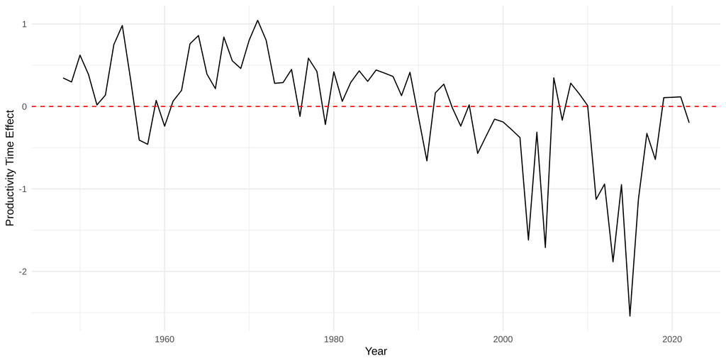

```r
re_time <- obj_ar$report(obj_ar$env$last.par.best)$re_time
ggplot() + geom_line(aes(x = minyear+0:(nyears-1), y = re_time)) + theme_minimal() + geom_hline(yintercept = 0, col = 'red', linetype = 'dashed') + xlab("Year") + ylab("Productivity Time Effect")
```

## Is the Year Effect Worth It?

- Compare models fitted to the same data by their marginal likelihood, for example with AIC.
- AIC = 2 × (negative log-likelihood) + 2 × (number of fixed effects). Lower is better.
- Take care near a boundary: a variance cannot go below zero, so small differences (around 2) are not decisive.
- Here the difference is large: the stocks share good and bad years.

```r
aic <- function(fit) 2*fit$objective + 2*length(fit$par)
c(no_year_effect = aic(fit), ar1_year_effect = aic(fit_ar))
```

```
 no_year_effect ar1_year_effect
       3847.620        3385.359
```

## Using RTMB’s AR Distribution

```r
set.seed(1)
parameters <- list(
  alpha0 = runif(1, 1, 3),
  re = rnorm(nstocks, 0, 0.1),
  logbeta = runif(nstocks, -1, 0),
  logsigma = runif(nstocks, -0.5, 0.5),
  logsigma_re = log(0.5),
  re_time = rep(0, nyears),
  logitphi = 0,
  logsigma_time = log(0.5)
)

negll_autoreg <- function(pars){

  getAll(pars, sox, warn = FALSE)
  beta <- exp(logbeta)

  sigma <- exp(logsigma)
  sigma_re <- exp(logsigma_re)
  sigma_time <- exp(logsigma_time)
  phi <- 2*plogis(logitphi)-1

  alpha_stock <- re + alpha0
  ADREPORT(alpha_stock)

  mu <- alpha_stock[stock] + re_time[time] - beta[stock]*spawners_scaled
  logRS <- OBS(logRS)

  ll <- dautoreg(re_time,phi=phi,scale=sqrt(sigma_time^2/(1-phi^2)), log=TRUE)

  ll <- ll + sum(dnorm(re, 0, sigma_re, log = TRUE))
  ll <- ll + sum(dnorm(logRS, mu, sigma[stock], log = TRUE))

  REPORT(mu)
  REPORT(re_time)

  return(-ll)
}

obj_autoreg <- MakeADFun(func = negll_autoreg, parameters = parameters, random = c("re", "re_time"), silent = TRUE)
fit_autoreg <- nlminb(obj_autoreg$par, obj_autoreg$fn, obj_autoreg$gr, control = list(eval.max = 1e4, iter.max = 1e4))
```

## As a Gauss Markov Random Field Distribution

- For the temporal random effect, we can write the joint distribution as a multivariate normal, with mean 0, and covariance, $\Sigma$,

$$\begin{align}
\Sigma_{ii} & = \epsilon^2/(1-\phi^2)\\
\Sigma_{ij} & = \epsilon^2/(1-\phi^2) \phi^{|t_i-t_j|}
\end{align}$$

- This covariance matrix is dense, which makes computation challenging, even for 75 years. Instead, we can write it in terms of the inverse, or precision matrix, $Q$, that is tridiagonal.
- You might consider this approach for spatial models such as those presented in `sdmTMB`.

```r
set.seed(1)
parameters <- list(
  alpha0 = runif(1, 1, 3),
  re = rnorm(nstocks, 0, 0.1),
  logbeta = runif(nstocks, -1, 0),
  logsigma = runif(nstocks, -0.5, 0.5),
  logsigma_re = log(0.5),
  re_time = rep(0, nyears),
  logitphi = 0,
  logsigma_time = log(0.5)
)

negll_gmrf <- function(pars){

  getAll(pars, sox, warn = FALSE)
  beta <- exp(logbeta)

  sigma <- exp(logsigma)
  sigma_re <- exp(logsigma_re)
  sigma_time <- exp(logsigma_time)
  phi <- 2*plogis(logitphi)-1

  alpha_stock <- re + alpha0
  ADREPORT(alpha_stock)

  mu <- alpha_stock[stock] + re_time[time] - beta[stock]*spawners_scaled
  logRS <- OBS(logRS)

  Q<-Matrix::spMatrix(nyears,nyears)
  diag(Q)<-c(1,rep(1+phi^2, nyears-2),1)
  Q[cbind(2:nyears,1:(nyears-1))] <- -phi
  Q[cbind(1:(nyears-1), 2:nyears)] <- -phi
  Q <- Q/(sigma_time^2)
  ll <- dgmrf(re_time, Q=Q, log=TRUE)

  ll <- ll + sum(dnorm(re, 0, sigma_re, log = TRUE))
  ll <- ll + sum(dnorm(logRS, mu, sigma[stock], log = TRUE))

  REPORT(mu)
  REPORT(re_time)

  return(-ll)
}

obj_gmrf <- MakeADFun(func = negll_gmrf, parameters = parameters, random = c("re", "re_time"), silent = TRUE)
fit_gmrf <- nlminb(obj_gmrf$par, obj_gmrf$fn, obj_gmrf$gr, control = list(eval.max = 1e4, iter.max = 1e4))
```

## What is Best?

- In this example, there is not much in it.
- Usually best to do what is most readable and understandable.
- Looping through each year is readable and simplest.

```r
init <- obj_gmrf$par
npar <- length(init)
microbenchmark::microbenchmark(
  "looped" = obj_ar$fn(init+rnorm(npar, 0, 0.1)),
  "autoreg" = obj_autoreg$fn(init+rnorm(npar, 0, 0.1)),
  "gmrf" = obj_gmrf$fn(init+rnorm(npar, 0, 0.1)),
  times = 10
    )
```

```
Unit: microseconds
    expr     min      lq     mean   median      uq      max neval
  looped 615.147 671.770 700.8283 698.2065 720.434  803.831    10
 autoreg 640.652 685.941 773.6719 714.5525 734.366 1282.635    10
    gmrf 632.102 668.407 736.5665 698.0275 738.775  971.999    10
```

## Random Time Steps

- If we fix $\phi = 0$ then the values are completely at random.
- `map = list()` allows us to set values to be constant.
  - Named for each parameter.
  - `NA` is fixed the value fixed at initial.
  - If factor levels are they same they are fitted as a single value/

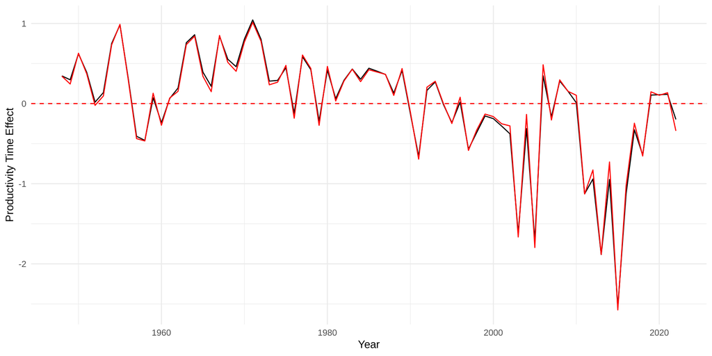

```r
set.seed(1)
parameters <- list(
  alpha0 = runif(1, 1, 3),
  re = rnorm(nstocks, 0, 0.1),
  logbeta = runif(nstocks, -1, 0),
  logsigma = runif(nstocks, -0.5, 0.5),
  logsigma_re = log(0.5),
  re_time = rep(0, nyears),
  logitphi = 0,
  logsigma_time = log(0.5)
)

obj <- MakeADFun(func = negll_ar, parameters = parameters,
  map = list(logitphi = factor(NA)), random = c("re", "re_time"), silent = TRUE)
fit <- nlminb(obj$par, obj$fn, obj$gr, control = list(eval.max = 1e4, iter.max = 1e4))

re_time2 <- obj$report(obj$env$last.par.best)$re_time
ggplot() + geom_line(aes(x = minyear+0:(nyears-1), y = re_time)) +
  geom_line(aes(x = minyear+0:(nyears-1), y = re_time2), col = 'red') +
theme_minimal() + geom_hline(yintercept = 0, col = 'red', linetype = 'dashed') + xlab("Year") + ylab("Productivity Time Effect")
```

## Practical

- What improvements can we make to this model?
- Some to try, comparing AIC each time:
  - A random walk in place of the AR(1): `dnorm(diff(re_time), 0, sigma_time)`, with `re_time[1]` given its own distribution
  - A separate time series for each stock, or for groups of stocks
  - Spawners from the three previous brood years (the Larkin model) for stocks with a dominant cycle line

## End of Module

- `RTMB` is set up to fit random effects super easily
- Laplace works with AD to efficiently marginalize over the random effects in many Gaussian models
- With great power comes great responsibility. Because you can, doesn’t mean you should